# SDSC6015 Stochastic Optimization and Online Learning

### City University of Hong Kong

# Chapter 1: Introduction to Optimization Problem in Machine Learning

> 2 September 2020

## Statistical learning protocol

- Observe $Z_1, \cdots , Z_N$. We assume that it is an i.i.d. sequence from an unknown probability distribution
- Make decision (or choose action/approximation) $a(Z_1,\cdots, Z_N)$
- Suffer an (average) loss $\mathbb{E} \ell (a(Z_1, \cdots, Z_n), Z)$ where $\ell$ is a given loss function.

**Objective**: Minimize the risk with respect to the decision $a$ $$\min_{a} \mathbb{E} \ell (a(Z_1, \ldots, Z_n), Z) $$ In most case of machine learning, the risk is the *empirical average* from individuals and $a$ is in parametric form associated with parameters denoed by $\theta$: $$\min_{\theta}L(\theta)= \min_{\theta} \sum_{j=1}^N \ell_j(\theta)$$ where $\ell_j(\theta)$ is the loss associated with the sample $Z_j$.

## Optimzation in Machine Learning Models

1. Linear Regression
2. Ridge Regression, Lasso Regression
3. Pinciple Component Analysis (PCA)
4. Logistic Regression
5. Support Vector Machine
6. Neural Network
7. Generative Adversarial Network (GAN)
8. Reinforcement Learning

# Linear Regression

$$\min_{\boldsymbol{\theta}} L(\boldsymbol{\theta})=\sum^N_{i=1}\left(\boldsymbol{\theta}^{\top}u^{(i)}-v^{(i)}\right)^2$$

[figure not shown]

We have a few samples of $\{(\mathbf{u}^{(i)},v^{(i)})\}^N_{i=1}$ pairs, $\mathbf{u}^{(i)}\in \mathbb{R}^n$, $v^{(i)}\in \mathbb{R}$. $\mathbf{u}^{(i)}$ is called the input variable and $v^{(i)}$ is called the output variable. (Here $\mathbf{u}^{(i)}$, $v^{(i)}$ can be anything in real life, for example, the height and the weight.) $$\dim (\mathbf{u})=n$$

[figure not shown]

How to calculate the corresponding $\hat{v}$ for a new test input $\hat{\mathbf{u}}$?

One simple idea is to approximate $\mathbf{v}$ by a linear function of $\mathbf{u}$.

$$h(u)=h_{\boldsymbol{\theta}}(\mathbf{u})=\theta_0 u_0+\theta_1 u_1+\cdots +\theta_n u_n$$

where $\mathbf{u}=(u_0,u_1,u_2,\cdots,u_n)$ and $\boldsymbol{\theta}=(\theta_0,\theta_1,\theta_2,\cdots,\theta_n)$ is the parameter. Here we add one dimension $u_0=1$ for $\mathbf{u}$ to represent the constant term.

[figure not shown]

$\boldsymbol{\theta}$ should be chosen so that $h_{\boldsymbol{\theta}}(\mathbf{u}^{(i)})$ and $v^{(i)}$ are "close" for all samples. The objective function of our problem can be formulated as
$$\min_{\boldsymbol{\theta}} L(\boldsymbol{\theta})=\sum^N_{i=1}\left(\boldsymbol{\theta}^{\top}\mathbf{u}^{(i)}-v^{(i)}\right)^2$$

[figure not shown]

The objective function can be rewritten into

\begin{align} L(\boldsymbol{\theta})&=\min_{\boldsymbol{\theta}} \sum^N_{i=1}\left(\boldsymbol{\theta}^{\top}\mathbf{u}^{(i)}-v^{(i)}\right)^2\\ &=(U\boldsymbol{\theta}-V)^\top (U\boldsymbol{\theta}-V)\\ &=\boldsymbol{\theta}^\top U^\top U \boldsymbol{\theta}-2 \boldsymbol{\theta}^\top U^\top V-V^\top V \end{align}

**Solving Linear Regression is a (unconstrained) quadratic optimization.**  
Take the derivitave and set it to zero,

$$U^\top U \boldsymbol{\theta}-U^\top V=0$$

If $U^\top U$ is full rank, $\boldsymbol{\theta}^*$ is given by:

$$\boldsymbol{\theta}^*=(U^\top U)^{-1}U^\top V$$

## Demonstration of Python Code

- `sklearn.linear_model`
- `LinearRegression().fit(input,output)`

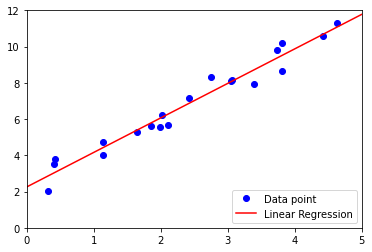

```python
import numpy as np
import matplotlib.pyplot as plt
from sklearn.linear_model import LinearRegression
dim=1; N=20
X = 5*np.random.random((N,dim))
y=2*(X)+1+2*np.random.random((N,1))

fig1=plt.figure()
ax1=fig1.add_subplot(1,1,1)
ax1.set_xlim(xmin =0, xmax =5)
ax1.set_ylim(ymin =0, ymax =12)
p0, =ax1.plot(X[:,0],y,"ob")

reg = LinearRegression().fit(X, y)
xplot=np.linspace(0,5,10)
yplot=reg.predict(xplot.reshape(-1,1))
p1, =ax1.plot(xplot,yplot,'r-')
plt.legend([p0,p1],["Data point","Linear Regression"],loc='lower right')
```

# Ridge Regression and Lasso Regression

$$\min_{\boldsymbol{\theta} } V(\boldsymbol{\theta})=L(\boldsymbol{\theta})+ \lambda R(\boldsymbol{\theta})$$

where **$L(\boldsymbol{\theta})$ is the squared loss**

$$L(\boldsymbol{\theta})= \sum^N_{i=1}\left(\boldsymbol{\theta}^{\top}\mathbf{u}^{(i)}-\mathbf{v}^{(i)}\right)^2$$

**$R$ is the regularization (penalty to achieve some important machine learning goal)**

- For Ridge Regression: $R(\boldsymbol{\theta})=\sum_{j=0}^n \theta_j^2$
- For Lasso (Least absolute shrinkage and selection operator) Regression: $R(\boldsymbol{\theta})=\sum_{j=0}^n |\theta_j|$

[figure not shown]

- Adding a regularization term to an error function can **control over-fitting by discouraging the coefficients from reaching large values**.
- Lasso regression can lead to **sparse model** by driving some coefficients to zero.

To see this, first notice that minimizing the above objective function is equivalent to minimizing

$$L(\boldsymbol{\theta})= \sum^N_{i=1}\left(\boldsymbol{\theta}^{\top}\mathbf{u}^{(i)}-\mathbf{v}^{(i)}\right)^2$$

subject to the constraint

$$R(\boldsymbol{\theta})\leq c$$

where $c$ is a constant and $\lambda$ can be seen as the Lagrange multiplier.

The coefficients are constrained by the feasible set so they will not grow too large.  
With a carefully chosen parameter, the solution of Lasso regression will rest on the axis, and the corresponding cosfficient reaches zero.

[figure not shown]

## Illustrative Python Code in 1D

**However, Ridge/Lasso shows their power only for high dim problem**

```python
import numpy as np
import matplotlib.pyplot as plt
from sklearn.linear_model import LinearRegression
from sklearn.linear_model import Lasso
from sklearn.linear_model import Ridge

X = np.linspace(0.0, 5.0, num=40)
y=2*(X)+1+5*np.random.random((40))

###############################################################
X=X.reshape((-1,1))
reg0 = LinearRegression().fit(X, y)
reg1 = Ridge(alpha=0.3).fit(X, y)
reg2 = Lasso(alpha=0.3).fit(X, y)
```

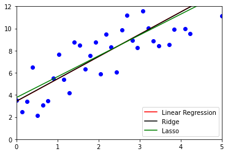

```python
fig1=plt.figure()
ax1=fig1.add_subplot(1,1,1)
ax1.set_xlim(xmin =0, xmax =5)
ax1.set_ylim(ymin =0, ymax =12)
p0, =ax1.plot(X,y,"ob")

xplot=np.linspace(0,5,10)
yplot0=reg0.predict(xplot.reshape(-1,1))
p1, =ax1.plot(xplot,yplot0,"-r")
yplot2=reg1.predict(xplot.reshape(-1,1))
p2, =ax1.plot(xplot,yplot2,"-k")
yplot1=reg2.predict(xplot.reshape(-1,1))
p3, =ax1.plot(xplot,yplot1,"-g")

plt.legend([p1,p2,p3],["Linear Regression","Ridge","Lasso"],loc='lower right')
```

## Application in compressive sensing: tomography reconstruction with L1 prior (Lasso)

[figure not shown]

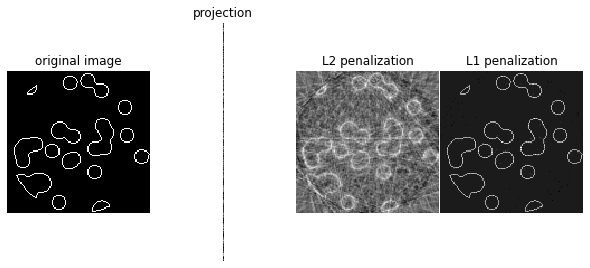

```python
# https://scikit-learn.org/stable/auto_examples/applications/plot_tomography_l1_reconstruction.html
import numpy as np
from scipy import sparse
from scipy import ndimage
from sklearn.linear_model import Lasso
from sklearn.linear_model import Ridge
import matplotlib.pyplot as plt


def _weights(x, dx=1, orig=0):
    x = np.ravel(x)
    floor_x = np.floor((x - orig) / dx).astype(np.int64)
    alpha = (x - orig - floor_x * dx) / dx
    return np.hstack((floor_x, floor_x + 1)), np.hstack((1 - alpha, alpha))


def _generate_center_coordinates(l_x):
    X, Y = np.mgrid[:l_x, :l_x].astype(np.float64)
    center = l_x / 2.
    X += 0.5 - center
    Y += 0.5 - center
    return X, Y

#Compute the tomography design matrix.
def build_projection_operator(l_x, n_dir):
    X, Y = _generate_center_coordinates(l_x)
    angles = np.linspace(0, np.pi, n_dir, endpoint=False)
    data_inds, weights, camera_inds = [], [], []
    data_unravel_indices = np.arange(l_x ** 2)
    data_unravel_indices = np.hstack((data_unravel_indices,
                                      data_unravel_indices))
    for i, angle in enumerate(angles):
        Xrot = np.cos(angle) * X - np.sin(angle) * Y
        inds, w = _weights(Xrot, dx=1, orig=X.min())
        mask = np.logical_and(inds >= 0, inds < l_x)
        weights += list(w[mask])
        camera_inds += list(inds[mask] + i * l_x)
        data_inds += list(data_unravel_indices[mask])
    proj_operator = sparse.coo_matrix((weights, (camera_inds, data_inds)))
    return proj_operator


def generate_synthetic_data():
    rs = np.random.RandomState(0)
    n_pts = 36
    x, y = np.ogrid[0:l, 0:l]
    mask_outer = (x - l / 2.) ** 2 + (y - l / 2.) ** 2 < (l / 2.) ** 2
    mask = np.zeros((l, l))
    points = l * rs.rand(2, n_pts)
    mask[(points[0]).astype(np.int), (points[1]).astype(np.int)] = 1
    mask = ndimage.gaussian_filter(mask, sigma=l / n_pts)
    res = np.logical_and(mask > mask.mean(), mask_outer)
    return np.logical_xor(res, ndimage.binary_erosion(res))


# Generate synthetic images, and projections
l = 128
proj_operator = build_projection_operator(l, l // 7)
data = generate_synthetic_data()
proj = proj_operator * data.ravel()[:, np.newaxis]
proj += 0.15 * np.random.randn(*proj.shape)

# Reconstruction with L2 (Ridge) penalization
rgr_ridge = Ridge(alpha=0.2)
rgr_ridge.fit(proj_operator, proj.ravel())
rec_l2 = rgr_ridge.coef_.reshape(l, l)

# Reconstruction with L1 (Lasso) penalization
# the best value of alpha was determined using cross validation
# with LassoCV
rgr_lasso = Lasso(alpha=0.001)
rgr_lasso.fit(proj_operator, proj.ravel())
rec_l1 = rgr_lasso.coef_.reshape(l, l)

plt.figure(figsize=(8, 3.3))
plt.subplot(141)
plt.imshow(data, cmap=plt.cm.gray, interpolation='nearest')
plt.axis('off')
plt.title('original image')
plt.subplot(142)
plt.imshow(proj, cmap=plt.cm.gray, interpolation='nearest')
plt.title('projection')
plt.axis('off')
plt.subplot(143)
plt.imshow(rec_l2, cmap=plt.cm.gray, interpolation='nearest')
plt.title('L2 penalization')
plt.axis('off')
plt.subplot(144)
plt.imshow(rec_l1, cmap=plt.cm.gray, interpolation='nearest')
plt.title('L1 penalization')
plt.axis('off')

plt.subplots_adjust(hspace=0.01, wspace=0.01, top=1, bottom=0, left=0,
                    right=1)

plt.show()
```

# Principle Component Analysis (PCA)

To find the maximal eigenvalue $u_1$ (with length 1) of the sample covariance matrix $S$

$$ S u_i = \lambda_i u_i$$

where $\lambda_1 \ge \lambda_2 \ge \ldots \ge \lambda_n\ge 0$

The positive definite matrix $S$

\begin{align} S&=\frac{1}{N}\sum^N_{i=1}(\mathbf{u}^{(i)}-\bar{\mathbf{u}})(\mathbf{u}^{(i)}-\bar{\mathbf{u}})^\top, \qquad \bar{\mathbf{u}}=\frac{1}{N}\sum^N_{i=1}\mathbf{u}^{(i)} \end{align}

- The largest eigenvector maximizes the Rayley quotient

  $$u_1 = \arg\max_{\|u\|_2=1} u^\top S u $$
- Introduce the Lagrangian multiplier $\lambda_1$, then $u_1$ solves the unconstrained quadratic optmization problem

$$\max_{\hat{u}_1}\ \ V(\hat{u}_1)=\hat{u}_1^\top S \hat{u}_1+\lambda_1(1- \hat{u}_1^\top \hat{u}_1)$$

[figure not shown]

- Consider a dataset $\{u^{(i)}\}^N_{i=1}$. We want to project the data onto to a space with lower dimensionality and the projected data should explain the variance of the original data to a maximal extent.
- The explained variance tells you how much information (variance) can be attributed to each of the principal components. So a **maximization** is used for the *principle component*.
- To begin with, we calculate the projection onto a one-dimensional space. Define the direction with a vector $\hat{u}_1$. Since only the direction of $\hat{u}_1$ matters to us, we let $\hat{u}_1$ be a unit vector so that $\hat{u}_1^\top \hat{u}_1=1$. The projected value of each $\mathbf{u}^{(i)}$ is $\hat{u}_1^\top \mathbf{u}^{(i)}$.

The **variance of the projected data** is given by

$$\frac{1}{N}\sum^N_{i=1}\{\hat{u}_1^\top \mathbf{u}^{(i)}- \hat{u}_1^\top \mathbf{\bar{u}}\}^2=\hat{u}_1^\top S \hat{u}_1$$

where \begin{align} S&=\frac{1}{N}\sum^N_{i=1}(\mathbf{u}^{(i)}-\bar{\mathbf{u}})(\mathbf{u}^{(i)}-\bar{\mathbf{u}})^\top\\ \bar{\mathbf{u}}&=\frac{1}{N}\sum^N_{i=1}\mathbf{u}^{(i)} \end{align}

subject to

$$\hat{u}_1^\top \hat{u}_1=1$$

Using the Lagrange mutiplier method, the problem can be reform as an unconstrained problem of

$$\max_{\hat{u}_1}\ \ \hat{u}_1^\top S \hat{u}_1+\lambda_1(1- \hat{u}_1^\top \hat{u}_1)$$

Taking the derivative with respect to $\hat{u}_1$ and set it to zero, we have

\begin{align} S\hat{u}_1&=\lambda_1 \hat{u}_1\\ \hat{u}_1^\top S \hat{u}_1&=\lambda_1 \end{align}

So the variance will be a maximum when we set $\hat{u}_1$ equal to the eigenvector having the largest eigenvalue $\lambda_1$. And $\hat{u}_1$ is the first principle component.

## Application: Reduce four-dim iris data to three-dim

[figure not shown]

```python
#https://scikit-learn.org/stable/auto_examples/decomposition/plot_pca_iris.html#sphx-glr-auto-examples-decomposition-plot-pca-iris-py
```

```
Dimensions: 150 x 4
```

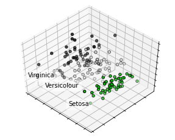

```python
import numpy as np
import matplotlib.pyplot as plt
from mpl_toolkits.mplot3d import Axes3D

from sklearn import decomposition
from sklearn import datasets

np.random.seed(5)

centers = [[1, 1], [-1, -1], [1, -1]]
iris = datasets.load_iris()
X = iris.data
print('Dimensions: %s x %s' % (X.shape[0], X.shape[1]))
y = iris.target

pca = decomposition.PCA(n_components=3)
pca.fit(X)
X = pca.transform(X)

fig = plt.figure(1, figsize=(4, 3))
ax = Axes3D(fig, rect=[0, 0, .95, 1], elev=48, azim=134)

for name, label in [('Setosa', 0), ('Versicolour', 1), ('Virginica', 2)]:
    ax.text3D(X[y == label, 0].mean(),
              X[y == label, 1].mean() + 1.5,
              X[y == label, 2].mean(), name,
              horizontalalignment='center',
              bbox=dict(alpha=.5, edgecolor='w', facecolor='w'))
# Reorder the labels to have colors matching the cluster results
y = np.choose(y, [1, 2, 0]).astype(np.float)
ax.scatter(X[:, 0], X[:, 1], X[:, 2], c=y, cmap=plt.cm.nipy_spectral,
           edgecolor='k')

ax.w_xaxis.set_ticklabels([])
ax.w_yaxis.set_ticklabels([])
ax.w_zaxis.set_ticklabels([])

plt.show()
```

# Logistic Regression for Binary Classification

Consider binary classification problem with $N$ training examples $\{\mathbf{u}^{(i)},v^{(i)}\}_{i=0}^N$, $v\in \{0,1\}$. The loss function (**Logistic Loss**) of logistic regression is

$$\max_{\boldsymbol{\theta}} V(\boldsymbol{\theta})=\sum^N_{i=1}\left\{-\log[1+\exp(-\boldsymbol{\theta}^\top\mathbf{u}^{(i)})]-[1-v^{(i)}]\boldsymbol{\theta}^\top\mathbf{u}^{(i)}\right\}$$

We will see why this form.

[figure not shown]

Similar to regression model, we have a few samples of $\{(\mathbf{u}^{(i)},v^{(i)})\}^N_{i=1}$ pairs. However, $v$ is now binary. i.e. $v^{(i)}\in \{0,1\}$.

[figure not shown]

Consider mapping the linear function to a value within $[0,1]$ with sigmoid function

$$g(z)=\frac{1}{1+\exp(-z)}$$

Define

$$h_{\theta}(\mathbf{u})=g(\boldsymbol{\theta}^\top \mathbf{u})=\frac{1}{1+\exp(-\boldsymbol{\theta}^\top\mathbf{u})}$$

Assume $v^{(i)}$ are independent Bernoulli random variables with probability of $h_{\boldsymbol{\theta}}(\mathbf{u}^{(i)})$. Their probability mass functions are given by

$$p(v^{(i)}|\mathbf{u}^{(i)};\boldsymbol{\theta})=[h_{\theta}(u^{(i)})]^{v^{(i)}}[1-h_{\theta}(u^{(i)})]^{1-v^{(i)}}$$

The likelihood function is

$$\prod^N_{i=1}\left\{[h_{\theta}(u^{(i)})]^{v^{(i)}}[1-h_{\theta}(u^{(i)})]^{1-v^{(i)}}\right\}$$

The loglikelihood is

\begin{align} &\sum^N_{i=1}\log \left\{[h_{\theta}(u^{(i)})]^{v^{(i)}}[1-h_{\theta}(u^{(i)})]^{1-v^{(i)}}\right\}\\ &=\sum^N_{i=1}\left\{v^{(i)}\log(h_{\theta}(u^{(i)}))+[1-v^{(i)}]\log[1-h_{\theta}(u^{(i)})]\right\}\\ &=\sum^N_{i=1}\big\{-v^{(i)}\log(1+\exp(-\boldsymbol{\theta}^\top u^{(i)}))+\\ &\ \ \ \ \ \ \ \ \ \ \ \ \ \ \ \ \ \ [1-v^{(i)}]\left[\log \exp(-\boldsymbol{\theta}^\top \mathbf{u})-\log(1+\exp(-\boldsymbol{\theta}^\top \mathbf{u}))\right]\big\}\\ &=\sum^N_{i=1}\left\{-\log[1+\exp(-\boldsymbol{\theta}^\top \mathbf{u}^{(i)})]-[1-v^{(i)}]\boldsymbol{\theta}^\top\mathbf{u}^{(i)}\right\} \end{align}

The problem can be formulate as $$\max_{\boldsymbol{\theta}} V(\boldsymbol{\theta})=\sum^N_{i=1}\left\{-\log[1+\exp(-\boldsymbol{\theta}^\top\mathbf{u}^{(i)})]-[1-v^{(i)}]\boldsymbol{\theta}^\top\mathbf{u}^{(i)}\right\}$$

## Application to Logistic Regression of 3-class Classification on Iris dataset

[figure not shown]

```python
#https://scikit-learn.org/stable/auto_examples/linear_model/plot_iris_logistic.html?highlight=logistic%20regression
```

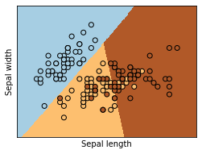

```python
import numpy as np
import matplotlib.pyplot as plt
from sklearn.linear_model import LogisticRegression
from sklearn import datasets

# import some data to play with
iris = datasets.load_iris()
X = iris.data[:, :2]  # we only take the first two features.
Y = iris.target

logreg = LogisticRegression(C=1e5)

# Create an instance of Logistic Regression Classifier and fit the data.
logreg.fit(X, Y)

# Plot the decision boundary. For that, we will assign a color to each
# point in the mesh [x_min, x_max]x[y_min, y_max].
x_min, x_max = X[:, 0].min() - .5, X[:, 0].max() + .5
y_min, y_max = X[:, 1].min() - .5, X[:, 1].max() + .5
h = .02  # step size in the mesh
xx, yy = np.meshgrid(np.arange(x_min, x_max, h), np.arange(y_min, y_max, h))
Z = logreg.predict(np.c_[xx.ravel(), yy.ravel()])

# Put the result into a color plot
Z = Z.reshape(xx.shape)
plt.figure(1, figsize=(4, 3))
plt.pcolormesh(xx, yy, Z, cmap=plt.cm.Paired)

# Plot also the training points
plt.scatter(X[:, 0], X[:, 1], c=Y, edgecolors='k', cmap=plt.cm.Paired)
plt.xlabel('Sepal length')
plt.ylabel('Sepal width')

plt.xlim(xx.min(), xx.max())
plt.ylim(yy.min(), yy.max())
plt.xticks(())
plt.yticks(())

plt.show()
```

# Support Vector Machine for classification

\begin{align} &\max_{\mathbf{w},b} \frac{1}{\|\mathbf{w}\|_2}\\ & s.t.\ \ v^{(i)}[\mathbf{w}^\top\mathbf{u}^{(i)}+b]\geq 1,\\ &\ \ \ \ \ \ \ \ \ i=1,...,N \end{align}

where $(\mathbf{u}^{(i)},v^{(i)} )$ are datapoints. $v\in \{-1,+1\}$

[figure not shown]

Consider binary classification problem with $N$ training examples $\{\mathbf{u}^{(i)},v^{(i)}\}_{i=0}^N$, where $u^{(i)}\in \mathbb{R}^{n}$, $v^{(i)}\in \{-1,1\}$.  
Assume that the samples can be seperated by a hyperplane. i.e., there exists a linear function of $\mathbf{u}$

$$h_{\mathbf{w},b}(u)=b+w_1u_1+w_2u_2+...+w_nu_n$$

such that for all $i=1,...,N$

$$ h_{\mathbf{w},b}(\mathbf{u}^{(i)}) \begin{cases} >0, \text{if}\ \ v^{(i)}=1 \\ <0, \text{if}\ \ v^{(i)}=-1 \end{cases} $$

We shall consider what is a "good" separating hyperplane.

[figure not shown]

The distance between the seperating hyperplane and the nearest data point can serve as an evaluation. This distance is called the margin,

$$ d(\mathbf{w},b)=\min_{i=1,...,N}d^i, $$

where $d^i$ is the *distance* from the data $i$ to the hyerplane

\begin{align} d^i=&\begin{cases} \frac{\mathbf{w}^\top u^{(i)}+b}{\|w\|}, \text{if}\ \ v^{(i)}=1 \\ -\frac{\mathbf{w}^\top u^{(i)}+b}{\|w\|}, \text{if}\ \ v^{(i)}=-1 \end{cases}\\ &=\frac{v^{(i)}[\mathbf{w}^\top \mathbf{u}^{(i)}+b]}{\|w\|} \end{align}

**A larger margin implies that the seperating hyperplane can distinguish the two different classes more significantly.** We aim at maximizing

\begin{align} \max_{\mathbf{w},b} d(\mathbf{w},b)= \frac{\min_{i=1,...,N} v^{(i)}[\mathbf{w}^\top \mathbf{u}^{(i)}+b]}{\|w\|} \end{align}

Let $\frac{\min_{i=1,...,N} v^{(i)}[\mathbf{w}^\top \mathbf{u}^{(i)}+b]}{\|w\|}=r$, obviously, $v^{(i)}[\mathbf{w}^\top \mathbf{u}^{(i)}+b]\geq r,\ i=1,...,N$.  
The problem can be rewritten as

\begin{align} &\max_{\mathbf{w},b,r} \frac{r}{\|w\|}\\ &s.t.\ \ v^{(i)}[\mathbf{w}^\top\mathbf{u}^{(i)}+b]\geq r, i=1,...,N \end{align}

Assume $r=1$, this will not change the optimal value of the problem. The problem becomes the **constrained** optimzation (*quadratic programming*)

\begin{align} &\min_{\mathbf{w},b} {\|w\|^2}\\ &s.t.\ \ v^{(i)}[\mathbf{w}^\top\mathbf{u}^{(i)}+b]\geq 1, i=1,...,N \end{align}

## Application of SVM to iris dataset

[figure not shown]

```python
#https://scikit-learn.org/stable/auto_examples/svm/plot_iris_svc.html#sphx-glr-auto-examples-svm-plot-iris-svc-py
```

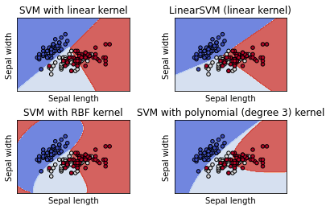

```python
import numpy as np
import matplotlib.pyplot as plt
from sklearn import svm, datasets


def make_meshgrid(x, y, h=.02):
    """Create a mesh of points to plot in

    Parameters
    ----------
    x: data to base x-axis meshgrid on
    y: data to base y-axis meshgrid on
    h: stepsize for meshgrid, optional

    Returns
    -------
    xx, yy : ndarray
    """
    x_min, x_max = x.min() - 1, x.max() + 1
    y_min, y_max = y.min() - 1, y.max() + 1
    xx, yy = np.meshgrid(np.arange(x_min, x_max, h),
                         np.arange(y_min, y_max, h))
    return xx, yy


def plot_contours(ax, clf, xx, yy, **params):
    Z = clf.predict(np.c_[xx.ravel(), yy.ravel()])
    Z = Z.reshape(xx.shape)
    out = ax.contourf(xx, yy, Z, **params)
    return out


# import some data to play with
iris = datasets.load_iris()
# Take the first two features. We could avoid this by using a two-dim dataset
X = iris.data[:, :2]
y = iris.target

# we create an instance of SVM and fit out data. We do not scale our
# data since we want to plot the support vectors
C = 1.0  # SVM regularization parameter
models = (svm.SVC(kernel='linear', C=C),
          svm.LinearSVC(C=C, max_iter=10000),
          svm.SVC(kernel='rbf', gamma=0.7, C=C),
          svm.SVC(kernel='poly', degree=3, gamma='auto', C=C))
models = (clf.fit(X, y) for clf in models)

# title for the plots
titles = ('SVM with linear kernel',
          'LinearSVM (linear kernel)',
          'SVM with RBF kernel',
          'SVM with polynomial (degree 3) kernel')

# Set-up 2x2 grid for plotting.
fig, sub = plt.subplots(2, 2)
plt.subplots_adjust(wspace=0.4, hspace=0.4)

X0, X1 = X[:, 0], X[:, 1]
xx, yy = make_meshgrid(X0, X1)

for clf, title, ax in zip(models, titles, sub.flatten()):
    plot_contours(ax, clf, xx, yy,
                  cmap=plt.cm.coolwarm, alpha=0.8)
    ax.scatter(X0, X1, c=y, cmap=plt.cm.coolwarm, s=20, edgecolors='k')
    ax.set_xlim(xx.min(), xx.max())
    ax.set_ylim(yy.min(), yy.max())
    ax.set_xlabel('Sepal length')
    ax.set_ylabel('Sepal width')
    ax.set_xticks(())
    ax.set_yticks(())
    ax.set_title(title)

plt.show()
```

# Neural Network

[figure not shown]

## One-hidden-layer neural network

Use the family of nonlinear function to approximate

$$ f(\mathbf{x}; \mathbf{w}, b )= \sigma(\mathbf{w}^\top \mathbf{x}+b)$$

- $\sigma(\cdot)$: activation function

[figure not shown]

- The class of functions in approximation:

$$y \approx \sum_{i=1}^m c_i f(\mathbf{x}; \mathbf{w}_i, b_i) $$

- The (emperical) mean squared loss $$L(\theta)= \sum_{j=1}^N \bigg | y_j -\sum_{i=1}^m c_i f(\mathbf{x}_j; \mathbf{w}_i, b_i) \bigg|^2 $$

  where all parameters are summarized as a variable $\theta= (c_i, \mathbf{w}_i, b_i)$, $i=1,\ldots, m$. $\mathbf{w}_i \in \mathbb{R}^n$.
- There are $m*(2+ n)$ unknowns.

## Exercise [Python programming]

- $\sigma$ is an activation function (sigmoid or RELU)
- Fit the Runge function function $y=\frac{1}{1+25 x^{2}}$ at $N$ equidistant points with $x_i\in [-1,1]$.
- Define the loss function: $L(\theta)$
- Compute the gradient of the loss function
- The input is a vector with the size $m*(n+2)=3m$
- Refer to the format of the MATLAB subroutine 'fminunc'.

## DNN: Deep Neural Network

- Multple layers
- Foundation of deep learning
- Non-convex optimization
- Challenging to train in practice
- Alchemy?

[figure not shown]

Loss surfaces of ResNet-110-noshort and DenseNet for CIFAR-10.  
Source:https://arxiv.org/pdf/1712.09913.pdf.

[figure not shown]

Training Deep neural networks is subtle and tricky in practice. Lots of experience and tricks from engineering are essential for the suceess of training.

```python
import torch
import torchvision
import torchvision.transforms as transforms
import matplotlib.pyplot as plt


transform = transforms.Compose(
    [transforms.ToTensor(),
     transforms.Normalize((0.5, 0.5, 0.5), (0.5, 0.5, 0.5))])

trainset = torchvision.datasets.CIFAR10(root='./data', train=True,
                                        download=True, transform=transform)
trainloader = torch.utils.data.DataLoader(trainset, batch_size=4,
                                          shuffle=True, num_workers=2)

testset = torchvision.datasets.CIFAR10(root='./data', train=False,
                                       download=True, transform=transform)
testloader = torch.utils.data.DataLoader(testset, batch_size=4,
                                         shuffle=False, num_workers=2)

classes = ('plane', 'car', 'bird', 'cat',
           'deer', 'dog', 'frog', 'horse', 'ship', 'truck')

#############################################################################3
import torch.nn as nn
import torch.nn.functional as F


class Net(nn.Module):
    def __init__(self):
        super(Net, self).__init__()
        self.conv1 = nn.Conv2d(3, 6, 5)
        self.pool = nn.MaxPool2d(2, 2)
        self.conv2 = nn.Conv2d(6, 16, 5)
        self.fc1 = nn.Linear(16 * 5 * 5, 120)
        self.fc2 = nn.Linear(120, 84)
        self.fc3 = nn.Linear(84, 10)

    def forward(self, x):
        x = self.pool(F.relu(self.conv1(x)))
        x = self.pool(F.relu(self.conv2(x)))
        x = x.view(-1, 16 * 5 * 5)
        x = F.relu(self.fc1(x))
        x = F.relu(self.fc2(x))
        x = self.fc3(x)
        return x


net = Net()
###################################################################################
import torch.optim as optim

criterion = nn.CrossEntropyLoss()
optimizer = optim.SGD(net.parameters(), lr=0.001, momentum=0.9)
###################################################################################
for epoch in range(2):  # loop over the dataset multiple times

    running_loss = 0.0
    for i, data in enumerate(trainloader, 0):
        # get the inputs; data is a list of [inputs, labels]
        inputs, labels = data

        # zero the parameter gradients
        optimizer.zero_grad()

        # forward + backward + optimize
        outputs = net(inputs)
        loss = criterion(outputs, labels)
        loss.backward()
        optimizer.step()

        # print statistics
        running_loss += loss.item()
        if i % 2000 == 1999:    # print every 2000 mini-batches
            print('[%d, %5d] loss: %.3f' %
                  (epoch + 1, i + 1, running_loss / 2000))
            running_loss = 0.0

print('Finished Training')
##################################################################################
dataiter = iter(testloader)
images, labels = dataiter.next()

# print images
imshow(torchvision.utils.make_grid(images))
print('GroundTruth: ', ' '.join('%5s' % classes[labels[j]] for j in range(4)))
net = Net()
net.load_state_dict(torch.load(PATH))
outputs = net(images)
_, predicted = torch.max(outputs, 1)

print('Predicted: ', ' '.join('%5s' % classes[predicted[j]]
                              for j in range(4)))
```

[output not shown]

# Generative Adversarial Network (GAN)

[figure not shown]

# Generative Adversarial Network (GAN)

$$\min_{G} \max_{D} V(G,D)=\int_x p_{data}(x)\log (D(x))dx+\int_z p_z(z) \log(1-D(g(z)))dz$$ $$V(G,D)\approx \sum_j \log (D(x_j)) + \sum_j \log(1-D(g(z_j)))$$

- $x\in X$ is the real data with $p_{data}$ as its probability density function (unknown, only data $x_j$ available)
- $z\in Z$ is the latent variable with $p_z$ as its probability density function (known and simple to sample $z_j$),
- $D:X\rightarrow [0,1]$ is the discriminator function and $G:Z\rightarrow X$ is the generator function.
- This is a min-max problem.

## Online GAN training websites

- https://poloclub.github.io/ganlab/
- https://reiinakano.com/gan-playground/

# Reinforcement Learning

[figure not shown]

Optimal Control (Infinite horizaon stochastic control; Markov Decision Process):

$$\min_{\pi}V_{\pi}(x_0)= \mathbb{E} \sum_{t=0}^\infty \alpha^{t} r(x_t,\pi(x_t)) $$

Bellman equation of Optimality

$$ V^*(i)= \min_{u\in U(i)}\sum_j p_{u}(r,j|i) [ r + \alpha V^*(j)]$$

```python
import gym
env = gym.make("CartPole-v1")
observation = env.reset()
for _ in range(1000):
  env.render()
  action = env.action_space.sample() # your agent here (this takes random actions)
  observation, reward, done, info = env.step(action)

  if done:
    observation = env.reset()
env.close()
```

# Summary

- All machine learning algorithms boil down to various optimizaton problems.
- They share a common challenge that the objective function is the sum of almost ``identical'' individual functions $$L(\theta)=\sum_{i} L_i(\theta)$$
- The non-smooth regularization (like $\ell_1$) $R(\theta)$ imposes additional difficulty
- Most machine learning packages nicely wrap the state-of-the-art optimization algorithms into **black-box**:

> `model.fit()`
- This course examines the basic theories and algorithms behind these methods, which have been developed recently.

## Stochastic Optimization and Online Learning

- The statistical learning theory and the convential optimzation method fail at addressing one the key features of the new massive data and the dynamic stream of data.
- Stochastic optimization use only a single or a smal fraction of the total dataset at each iteration step.
- Online learning is more general and even has no probabilistic assumption of the data $Z_1,\ldots, Z_N,\ldots$.